# LAD border changes

Tom van Schaik

2022-01-21

### Project description

Effect of cohesin looping on genome architecture, from the perspective of the nuclear lamina.

### Introduction

Look whether LAD border class change after protein depletions, to prove the point that CTCF and cohesin are not involved in LAD border positioning. Or see otherwise.

This analysis is similar to a previous document, but instead of showing borders without active genes, I specifically look at LAD borders with genes.

### Method

Use HMM models of the various experiments, and compare LAD border positioning with the LAD borders defined in the parental data.

### Set-up

Set the parameters and list the data.

```r
library(GenomicRanges)
library(rtracklayer)
library(tidyverse)
```

```r
library(ggbeeswarm)
library(ggplot2)
library(broom)

# Prepare output
output_dir <- "ts220118_LAD_border_changes_active_genes"
dir.create(output_dir, showWarnings = FALSE)

# Load input
input_dir <- "ts220113_CTCF_enrichment_at_LAD_borders"
LADs <- readRDS(file.path(input_dir, "LADs_pA.rds"))
LAD_borders <- readRDS(file.path(input_dir, "LAD_borders_pA.rds"))

input_dir <- "ts220113_effect_of_CTCF_depletion_on_LAD_borders"
bin_size <- readRDS(file.path(input_dir, "bin_size.rds"))
metadata_damid <- readRDS(file.path(input_dir, "metadata_damid.rds"))
damid <- readRDS(file.path(input_dir, "damid.rds"))

# Select input
LADs <- LADs[[1]]
LAD_borders <- LAD_borders[[1]]
LAD_borders <- LAD_borders[LAD_borders$ovl_gene == T]

bins <- damid
mcols(bins) <- NULL
```

```r
library(knitr)
opts_chunk$set(fig.width = 8, fig.height = 3.5, cache = T,
               dev=c('png', 'pdf'), fig.path = file.path(output_dir, "figures/"))

pdf.options(useDingbats = FALSE)
```

```r
LoadBed <- function(metadata, column, reduce = F, size_filter = F) {
  # Load LADs as GRangesList from metadata object
  bed <- GRangesList()
  for (i in 1:nrow(metadata)) {
    f.name <- (metadata %>% pull(column))[i]
    f.import <- import(f.name)
    if (reduce) {
      f.import <- GenomicRanges::reduce(f.import, min.gapwidth = 50e3)
    }
    if (size_filter) {
      f.import <- f.import[width(f.import) > 50e3]
    }
    f.import$sample <- metadata$sample[i]
    f.import <- f.import[seqnames(f.import) %in% c(paste0("chr", 1:22), "chrX")]
    bed <- c(bed, GRangesList(f.import))
  }
  names(bed) <- metadata$sample
  bed
}

LADBorders <- function(LADs, bins, min.distance = 0) {
  # Given a (named) GRangesList of LADs, return a GRangesList with borders
  # Strand information defines left (+) or right (-) border
  # Also, require complete bin object to determine chromosome start and end

  cells <- names(LADs)
  LAD.borders <- GRangesList()

  for (cell in cells ) {

    # Get LADs and bins for cell
    cell.LADs <- LADs[[cell]]
    cell.bins <- bins

    # Remove small iLADs and remove small LADs
    cell.LADs <- GenomicRanges::reduce(cell.LADs, min.gapwidth = min.distance)
    cell.LADs <- cell.LADs[width(cell.LADs) > min.distance]

    # Get borders
    cell.borders <- c(GRanges(seqnames = seqnames(cell.LADs),
                              ranges = IRanges(start = start(cell.LADs),
                                               end = start(cell.LADs)),
                              strand = "+"),
                      GRanges(seqnames = seqnames(cell.LADs),
                              ranges = IRanges(start = end(cell.LADs),
                                               end = end(cell.LADs)),
                              strand = "-"))
    cell.borders <- sort(cell.borders, ignore.strand = T)

    # Get start and end of the chromosome and filter overlapping borders
    chromosome.ends <- c(cell.bins[! duplicated(as.character(seqnames(cell.bins)))],
                         rev(cell.bins)[! duplicated(as.character(seqnames(rev(cell.bins))))])
    chromosome.ends <- flank(chromosome.ends, 5000, both = T)

    cell.borders <- cell.borders[! overlapsAny(cell.borders,
                                               chromosome.ends,
                                               ignore.strand = T)]

    cell.borders$cell <- cell

    LAD.borders <- c(LAD.borders, GRangesList(cell.borders))
  }

  names(LAD.borders) <- cells
  LAD.borders

}

grMid = function(gr) {
  start(gr) <- end(gr) <- rowMeans(cbind(start(gr), end(gr)))
  gr
}
```

### 1. Distance to closest border

First, load LADs.

```r
# Prepare LAD metadata
metadata_lads <- metadata_damid %>%
  filter(! condition %in% c("CTCF", "CTCFNQ")) %>%
  mutate(lad_file = file.path(paste0("../results_NQ/HMM/bin-", bin_size),
                              str_replace(file, ".norm.txt.gz", "_AD.bed.gz")))

LAD_list <- LoadBed(metadata_lads, "lad_file", reduce = T, size_filter = T)


# Prepare borders
LAD_border_list <- LADBorders(LAD_list, bins)
```

I will start simple: determine the distance from the selected borders to the closest border. And plot this distance.

Also filter for nearby borders to prevent comparisons with the wrong LAD when the entire LAD is not called in a certain condition.

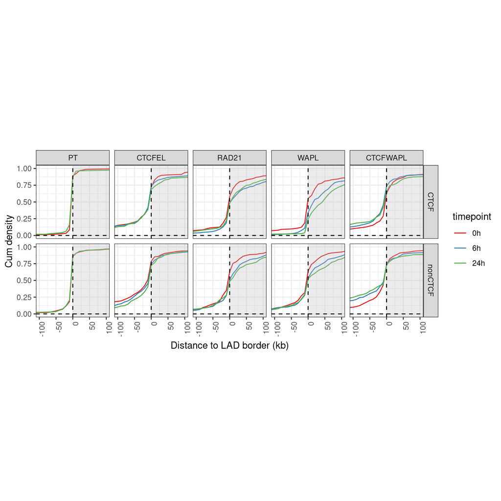

```r
# For all samples, determine distance to nearest border
border_distance <- tibble()

for (sample in metadata_lads$sample) {

  # Get borders for sample
  LAD_sample <- LAD_list[[sample]]
  LAD_border_sample <- LAD_border_list[[sample]]

  # Distance to nearest border
  dis <- as_tibble(distanceToNearest(LAD_borders, LAD_border_sample, ignore.strand = T)) %>%
    rename_all(~ c("border_idx", "sample_idx", "distance"))

  # Filter and add metadata
  dis <- dis %>%
    arrange(sample_idx, distance) %>%
    filter(! duplicated(sample_idx)) %>%
    mutate(sample = sample) %>%
    mutate(border_strand = as.character(strand(LAD_borders))[border_idx],
           sample_strand = as.character(strand(LAD_border_sample))[sample_idx],
           border_within_lad = overlapsAny(LAD_borders[border_idx], LAD_sample,
                                           ignore.strand = T),
           sample_within_lad = overlapsAny(LAD_border_sample[sample_idx], LADs,
                                           ignore.strand = T)) %>%
    mutate(distance = case_when(sample_within_lad == T ~ distance,
                                T ~ - distance))

  # Add to all border distances
  border_distance <- bind_rows(border_distance,
                               dis)

}

# Prepare for plotting
border_distance <- border_distance %>%
  separate(sample, c("condition", "timepoint"), remove = F) %>%
  mutate(condition = factor(condition, levels(metadata_lads$condition)),
         timepoint = factor(timepoint, levels(metadata_lads$timepoint)),
         distance_kb = distance / 1e3,
         distance_kb = (distance_kb %/% 10) * 10) %>%
  filter(timepoint != "96h") %>%
  mutate(CTCF = LAD_borders$CTCF[border_idx],
         CTCF_strand = LAD_borders$CTCF_strand[border_idx],
         CTCF_strand = factor(CTCF_strand, c("outwards", "inwards", "ambiguous", "nonCTCF")))

# Plot this
border_distance %>%
  ggplot(aes(x = distance_kb, col = timepoint)) +
  stat_ecdf(geom = "line") +
  annotate("rect", xmin = 0, xmax = Inf, ymin = -Inf, ymax = Inf,
           fill = "grey", alpha = 0.3) +
  geom_hline(yintercept = 0, col = "black", linetype = "dashed") +
  geom_vline(xintercept = 0, col = "black", linetype = "dashed") +
  facet_grid(CTCF ~ condition) +
  coord_cartesian(xlim = c(-100, 100)) +
  xlab("Distance to LAD border (kb)") +
  ylab("Cum density") +
  scale_color_brewer(palette = "Set1") +
  theme_bw() +
  theme(aspect.ratio = 1,
        axis.text.x = element_text(angle = 90, hjust = 1))
```

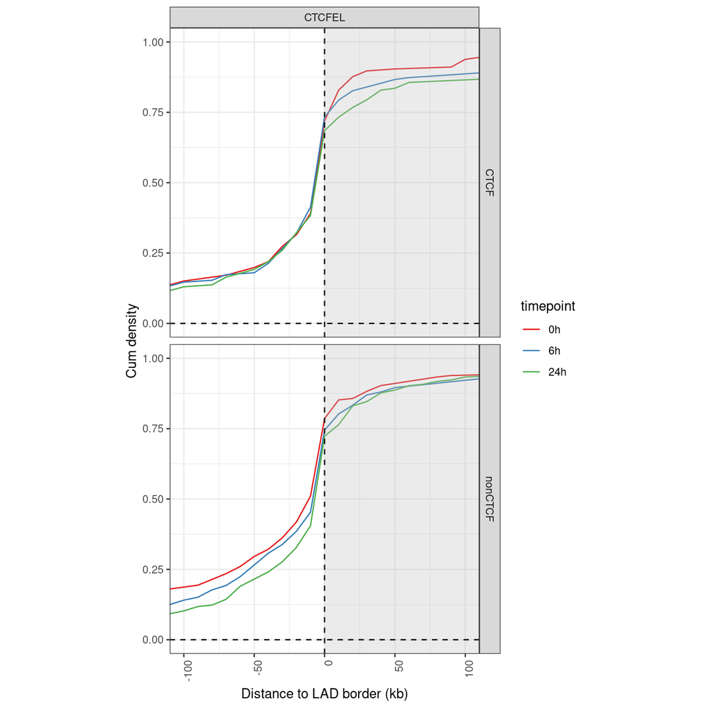

```r
border_distance %>%
  filter(condition == "CTCFEL") %>%
  ggplot(aes(x = distance_kb, col = timepoint)) +
  stat_ecdf(geom = "line") +
  annotate("rect", xmin = 0, xmax = Inf, ymin = -Inf, ymax = Inf,
           fill = "grey", alpha = 0.3) +
  geom_hline(yintercept = 0, col = "black", linetype = "dashed") +
  geom_vline(xintercept = 0, col = "black", linetype = "dashed") +
  facet_grid(CTCF ~ condition) +
  coord_cartesian(xlim = c(-100, 100)) +
  xlab("Distance to LAD border (kb)") +
  ylab("Cum density") +
  scale_color_brewer(palette = "Set1") +
  theme_bw() +
  theme(aspect.ratio = 1,
        axis.text.x = element_text(angle = 90, hjust = 1))
```

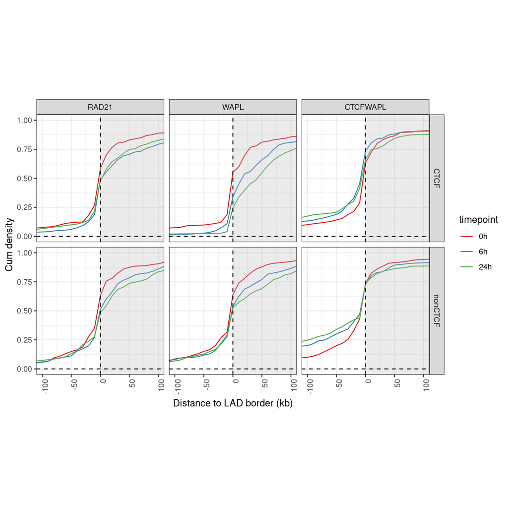

```r
border_distance %>%
  filter(condition %in% c("RAD21", "WAPL", "CTCFWAPL")) %>%
  ggplot(aes(x = distance_kb, col = timepoint)) +
  stat_ecdf(geom = "line") +
  annotate("rect", xmin = 0, xmax = Inf, ymin = -Inf, ymax = Inf,
           fill = "grey", alpha = 0.3) +
  geom_hline(yintercept = 0, col = "black", linetype = "dashed") +
  geom_vline(xintercept = 0, col = "black", linetype = "dashed") +
  facet_grid(CTCF ~ condition) +
  coord_cartesian(xlim = c(-100, 100)) +
  xlab("Distance to LAD border (kb)") +
  ylab("Cum density") +
  scale_color_brewer(palette = "Set1") +
  theme_bw() +
  theme(aspect.ratio = 1,
        axis.text.x = element_text(angle = 90, hjust = 1))
```

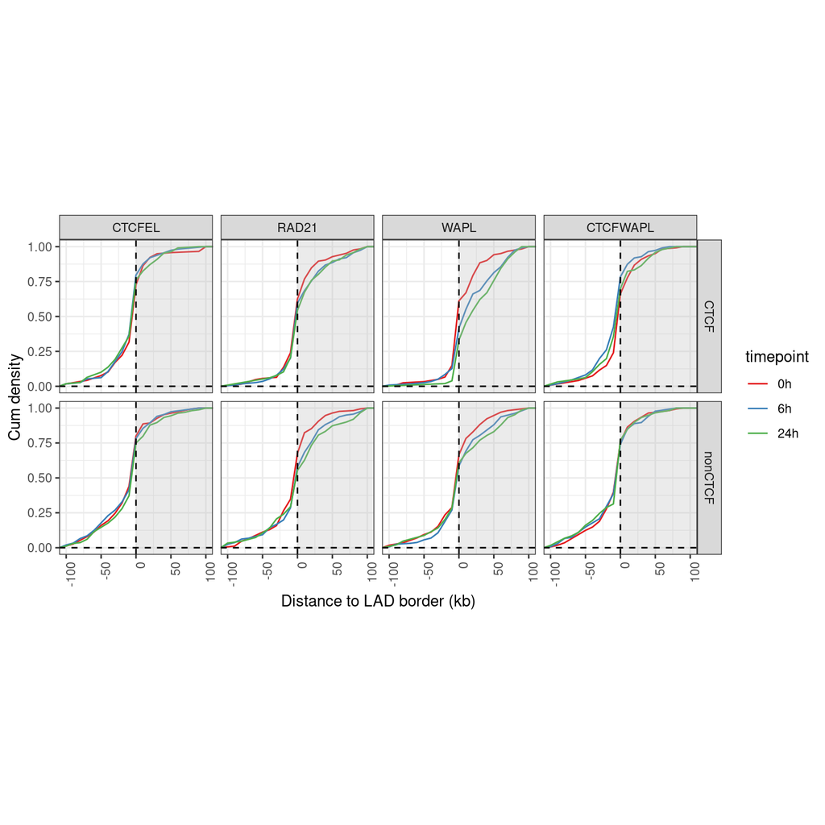

```r
# Plot this - assuming shift less than 100kb and removing PT
border_distance %>%
  filter(condition != "PT",
         distance_kb > -101, distance_kb < 101) %>%
  ggplot(aes(x = distance_kb, col = timepoint)) +
  stat_ecdf(geom = "line") +
  annotate("rect", xmin = 0, xmax = Inf, ymin = -Inf, ymax = Inf,
           fill = "grey", alpha = 0.3) +
  geom_hline(yintercept = 0, col = "black", linetype = "dashed") +
  geom_vline(xintercept = 0, col = "black", linetype = "dashed") +
  facet_grid(CTCF ~ condition) +
  coord_cartesian(xlim = c(-100, 100)) +
  xlab("Distance to LAD border (kb)") +
  ylab("Cum density") +
  scale_color_brewer(palette = "Set1") +
  theme_bw() +
  theme(aspect.ratio = 1,
        axis.text.x = element_text(angle = 90, hjust = 1))
```

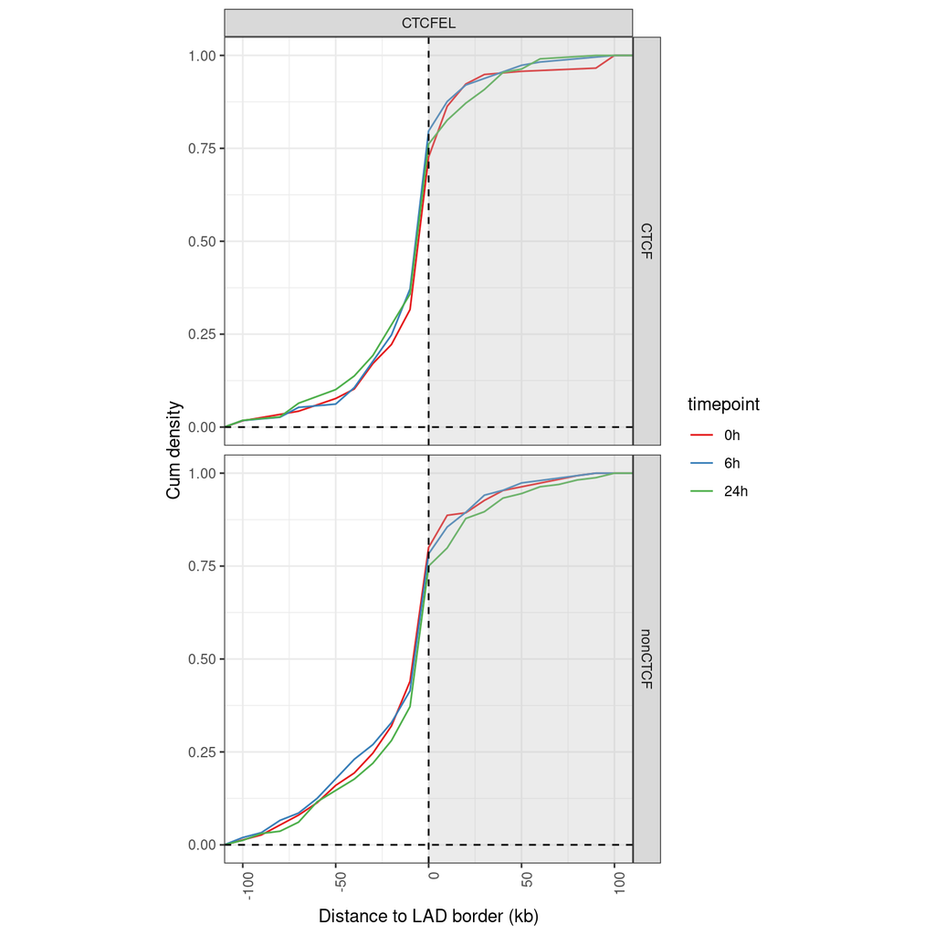

```r
border_distance %>%
  filter(condition == "CTCFEL",
         distance_kb > -101, distance_kb < 101) %>%
  ggplot(aes(x = distance_kb, col = timepoint)) +
  stat_ecdf(geom = "line") +
  annotate("rect", xmin = 0, xmax = Inf, ymin = -Inf, ymax = Inf,
           fill = "grey", alpha = 0.3) +
  geom_hline(yintercept = 0, col = "black", linetype = "dashed") +
  geom_vline(xintercept = 0, col = "black", linetype = "dashed") +
  facet_grid(CTCF ~ condition) +
  coord_cartesian(xlim = c(-100, 100)) +
  xlab("Distance to LAD border (kb)") +
  ylab("Cum density") +
  scale_color_brewer(palette = "Set1") +
  theme_bw() +
  theme(aspect.ratio = 1,
        axis.text.x = element_text(angle = 90, hjust = 1))
```

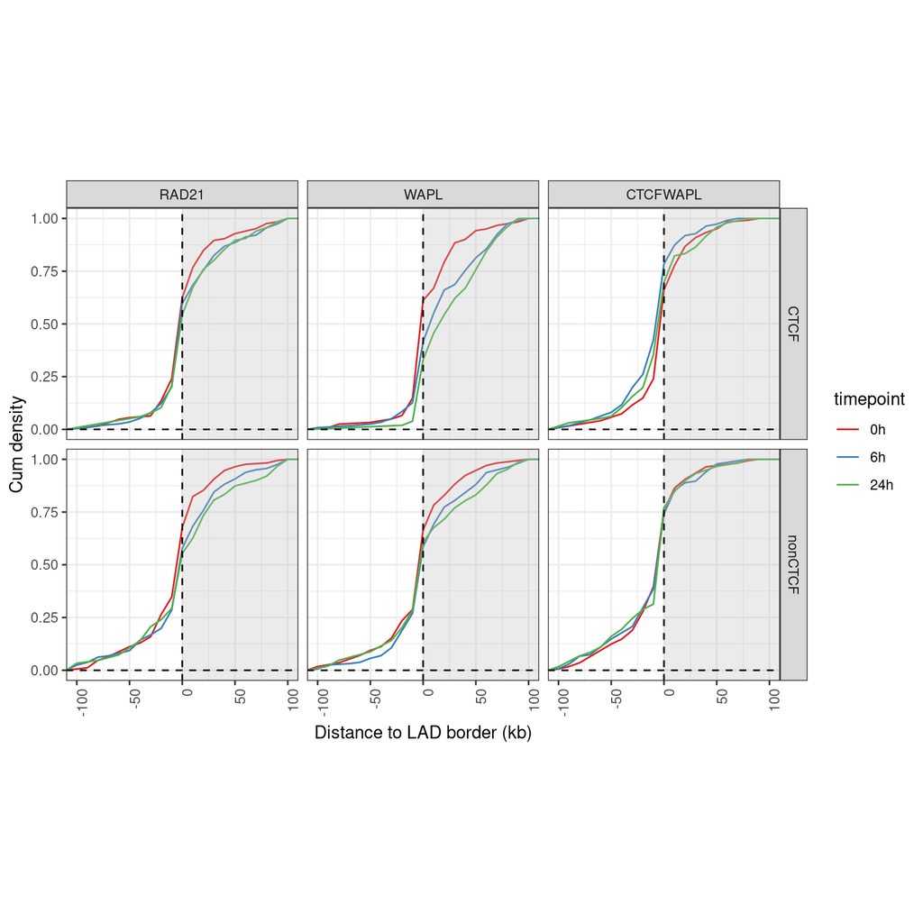

```r
border_distance %>%
  filter(condition %in% c("RAD21", "WAPL", "CTCFWAPL"),
         distance_kb > -101, distance_kb < 101) %>%
  ggplot(aes(x = distance_kb, col = timepoint)) +
  stat_ecdf(geom = "line") +
  annotate("rect", xmin = 0, xmax = Inf, ymin = -Inf, ymax = Inf,
           fill = "grey", alpha = 0.3) +
  geom_hline(yintercept = 0, col = "black", linetype = "dashed") +
  geom_vline(xintercept = 0, col = "black", linetype = "dashed") +
  facet_grid(CTCF ~ condition) +
  coord_cartesian(xlim = c(-100, 100)) +
  xlab("Distance to LAD border (kb)") +
  ylab("Cum density") +
  scale_color_brewer(palette = "Set1") +
  theme_bw() +
  theme(aspect.ratio = 1,
        axis.text.x = element_text(angle = 90, hjust = 1))
```

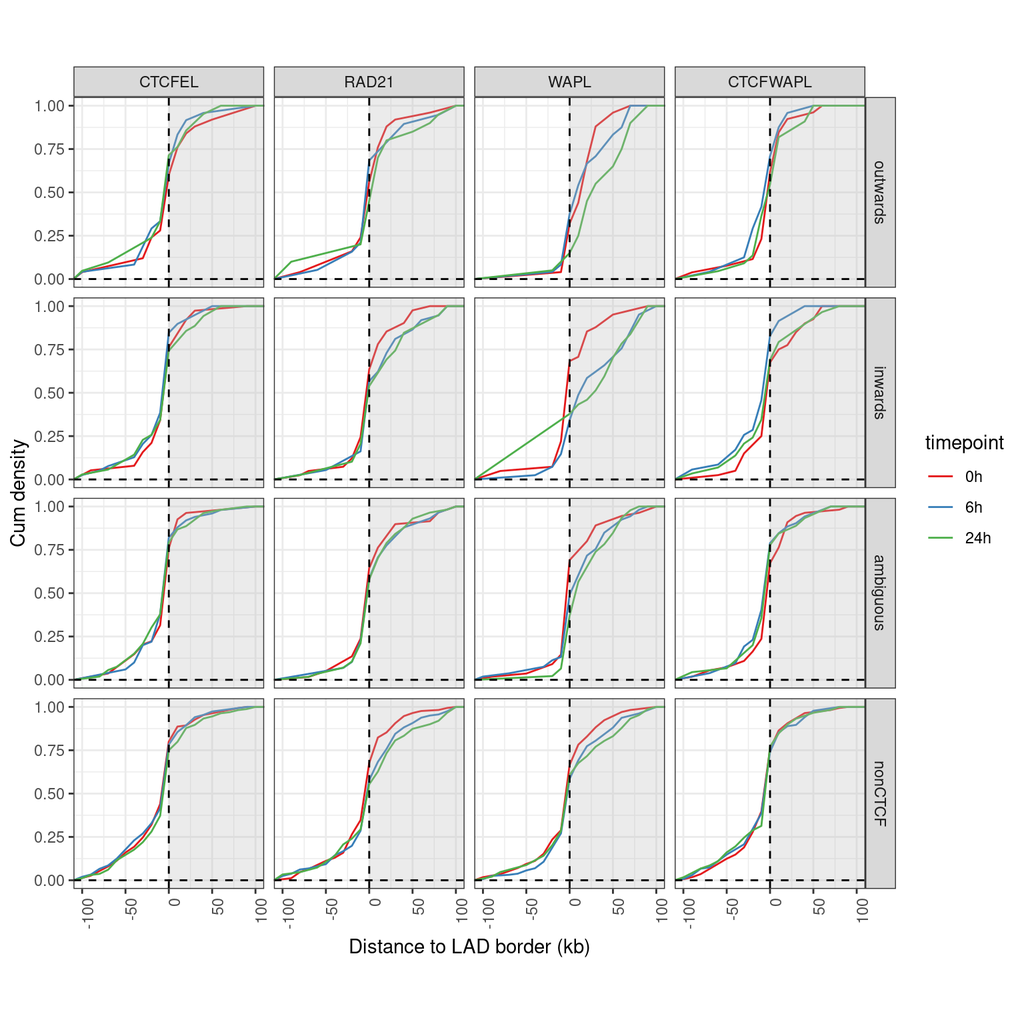

```r
# Plot this - assuming shift less than 100kb and removing PT, with CTCF strand information
border_distance %>%
  filter(condition != "PT",
         distance_kb > -101, distance_kb < 101) %>%
  ggplot(aes(x = distance_kb, col = timepoint)) +
  stat_ecdf(geom = "line") +
  annotate("rect", xmin = 0, xmax = Inf, ymin = -Inf, ymax = Inf,
           fill = "grey", alpha = 0.3) +
  geom_hline(yintercept = 0, col = "black", linetype = "dashed") +
  geom_vline(xintercept = 0, col = "black", linetype = "dashed") +
  facet_grid(CTCF_strand ~ condition) +
  coord_cartesian(xlim = c(-100, 100)) +
  xlab("Distance to LAD border (kb)") +
  ylab("Cum density") +
  scale_color_brewer(palette = "Set1") +
  theme_bw() +
  theme(aspect.ratio = 1,
        axis.text.x = element_text(angle = 90, hjust = 1))
```

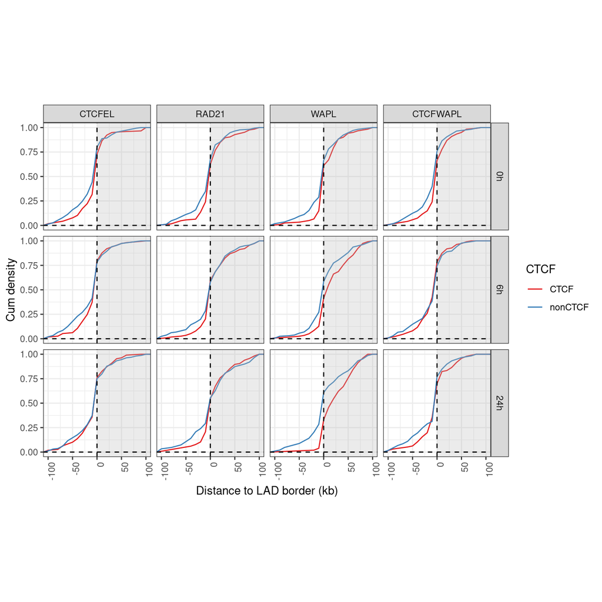

```r
# Plot this - assuming shift less than 100kb and removing PT, by border type
border_distance %>%
  filter(condition != "PT",
         distance_kb > -101, distance_kb < 101) %>%
  ggplot(aes(x = distance_kb, col = CTCF)) +
  stat_ecdf(geom = "line") +
  annotate("rect", xmin = 0, xmax = Inf, ymin = -Inf, ymax = Inf,
           fill = "grey", alpha = 0.3) +
  geom_hline(yintercept = 0, col = "black", linetype = "dashed") +
  geom_vline(xintercept = 0, col = "black", linetype = "dashed") +
  facet_grid(timepoint ~ condition) +
  coord_cartesian(xlim = c(-100, 100)) +
  xlab("Distance to LAD border (kb)") +
  ylab("Cum density") +
  scale_color_brewer(palette = "Set1") +
  theme_bw() +
  theme(aspect.ratio = 1,
        axis.text.x = element_text(angle = 90, hjust = 1))
```

This looks sort of as expected. Good.

### 2. Linear models of border slopes

A different approach - use the border to determine a linear slope and compare slope / intercept.

```r
# Get border bins
max_distance <- 3e4

bins_mid <- grMid(bins)

dis <- as_tibble(distanceToNearest(bins_mid, LAD_borders, ignore.strand = T)) %>%
  rename_at(1:2, ~ c("bin_idx", "border_idx")) %>%
  filter(distance < max_distance) %>%
  mutate(LAD_ovl = overlapsAny(bins_mid[bin_idx], LADs),
         distance = case_when(LAD_ovl == T ~ distance,
                              T ~ -distance),
         distance = distance / 1e3,
         distance = (distance %/% 10) * 10)

# Add DamID values
dis <- bind_cols(dis,
                 as_tibble(mcols(damid))[dis$bin_idx, ] %>%
                   dplyr::select(one_of(metadata_lads$sample))) %>%
  arrange(border_idx, distance) %>%
  dplyr::select(-bin_idx, -LAD_ovl) %>%
  gather(key, value, -border_idx, -distance) %>%
  drop_na()

# Linear models
border_models <- dis %>%
  group_by(key, border_idx) %>%
  do(border_fit = tidy(lm(value ~ distance, data = .))) %>%
  unnest(border_fit)
```

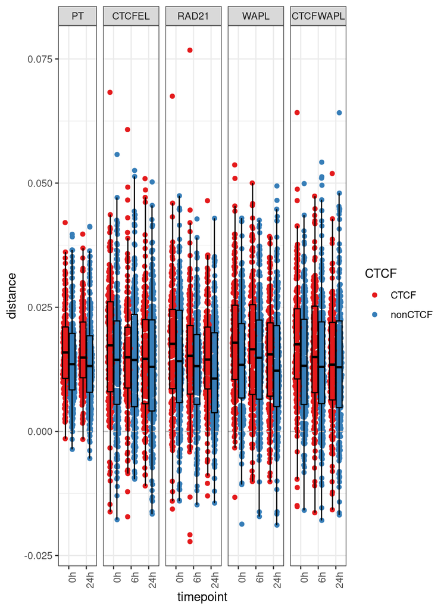

```r
# Prepare for plotting
border_models_plot <- border_models %>%
  mutate(term = str_remove_all(term, "\\(|\\)")) %>%
  dplyr::select(key, border_idx, term, estimate) %>%
  spread(term, estimate) %>%
  separate(key, c("condition", "timepoint"), remove = F) %>%
  mutate(condition = factor(condition, levels(metadata_lads$condition)),
         timepoint = factor(timepoint, levels(metadata_lads$timepoint))) %>%
  mutate(CTCF = LAD_borders$CTCF[border_idx]) %>%
  filter(timepoint != "96h")

# Plot models
border_models_plot %>%
  ggplot(aes(x = timepoint, y = distance, col = CTCF, group = interaction(timepoint, CTCF))) +
  geom_quasirandom(dodge.width = 0.8) +
  geom_hline(yintercept = 0, col = "grey", linetype = "dashed") +
  geom_boxplot(col = "black", outlier.shape = NA, fill = NA) +
  facet_grid(. ~ condition, scale = "free_x", space = "free_x") +
  scale_color_brewer(palette = "Set1") +
  theme_bw() +
  theme(#aspect.ratio = 3,
        axis.text.x = element_text(angle = 90, hjust = 1))
```

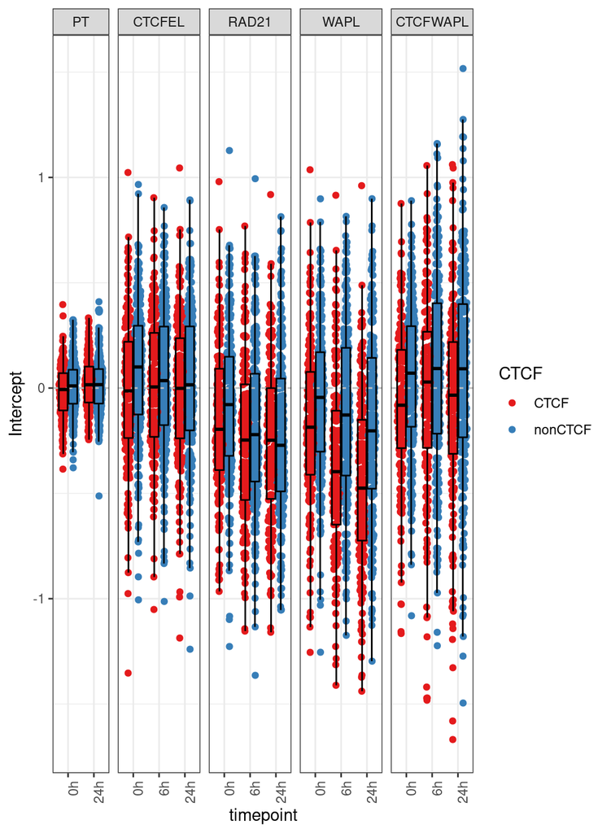

```r
border_models_plot %>%
  ggplot(aes(x = timepoint, y = Intercept, col = CTCF, group = interaction(timepoint, CTCF))) +
  geom_quasirandom(dodge.width = 0.8) +
  geom_hline(yintercept = 0, col = "grey", linetype = "dashed") +
  geom_boxplot(col = "black", outlier.shape = NA, fill = NA) +
  facet_grid(. ~ condition, scale = "free_x", space = "free_x") +
  scale_color_brewer(palette = "Set1") +
  theme_bw() +
  theme(#aspect.ratio = 3,
        axis.text.x = element_text(angle = 90, hjust = 1))
```

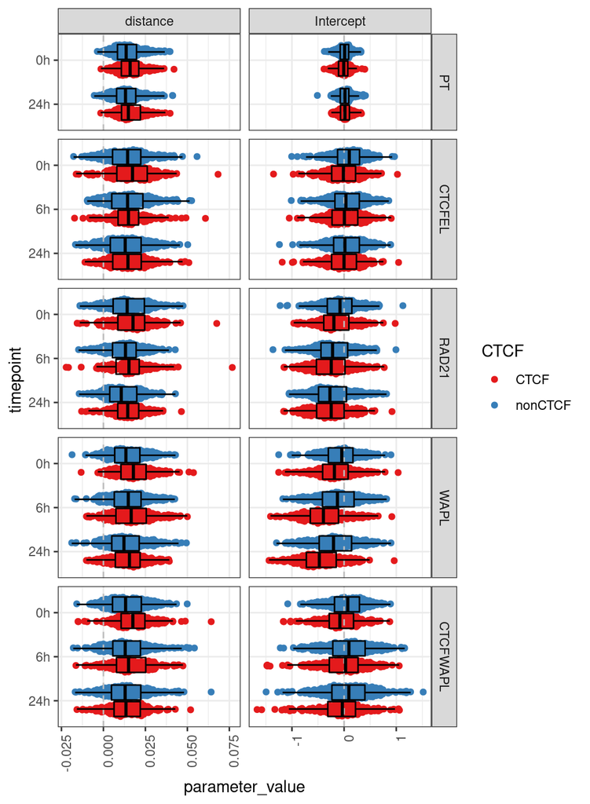

```r
border_models_plot %>%
  mutate(timepoint = factor(timepoint, rev(levels(metadata_lads$timepoint)))) %>%
  gather(parameter, parameter_value, distance, Intercept) %>%
  ggplot(aes(x = timepoint, y = parameter_value,
             col = CTCF, group = interaction(timepoint, CTCF))) +
  geom_quasirandom(dodge.width = 0.8) +
  geom_hline(yintercept = 0, col = "grey", linetype = "dashed") +
  geom_boxplot(col = "black", outlier.shape = NA, fill = NA) +
  coord_flip() +
  facet_grid(condition ~ parameter, scale = "free", space = "free_y") +
  scale_color_brewer(palette = "Set1") +
  theme_bw() +
  theme(#aspect.ratio = 1,
        axis.text.x = element_text(angle = 90, hjust = 1))
```

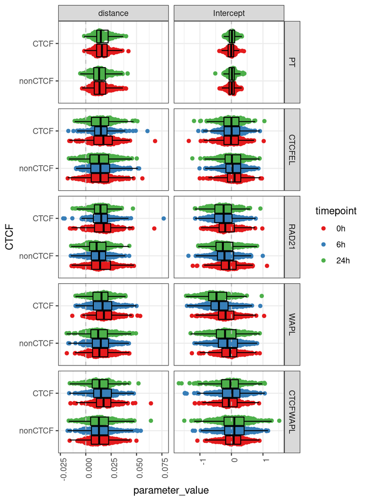

```r
border_models_plot %>%
  mutate(CTCF = factor(CTCF, c("nonCTCF", "CTCF"))) %>%
  gather(parameter, parameter_value, distance, Intercept) %>%
  ggplot(aes(x = CTCF, y = parameter_value,
             col = timepoint, group = interaction(CTCF, timepoint))) +
  geom_quasirandom(dodge.width = 0.8) +
  geom_hline(yintercept = 0, col = "grey", linetype = "dashed") +
  geom_boxplot(col = "black", outlier.shape = NA, fill = NA) +
  coord_flip() +
  facet_grid(condition ~ parameter, scale = "free", space = "free_y") +
  scale_color_brewer(palette = "Set1") +
  theme_bw() +
  theme(#aspect.ratio = 1,
    axis.text.x = element_text(angle = 90, hjust = 1))
```

```r
# Determine significance - between border classes
border_models_plot %>%
  group_by(condition, timepoint) %>%
  do(test_slope = tidy(wilcox.test(distance  ~ CTCF, data = .))) %>%
  unnest(test_slope) %>%
  mutate(padj = p.adjust(p.value),
         sign = padj < 0.05)
```

```
## # A tibble: 14 × 8
##    condition timepoint statistic  p.value method       alternative    padj sign
##    <fct>     <fct>         <dbl>    <dbl> <chr>        <chr>         <dbl> <lgl>
##  1 PT        0h            19116 0.0231   Wilcoxon ra… two.sided   0.208   FALSE
##  2 PT        24h           19367 0.0118   Wilcoxon ra… two.sided   0.118   FALSE
##  3 CTCFEL    0h            19407 0.0105   Wilcoxon ra… two.sided   0.116   FALSE
##  4 CTCFEL    6h            17502 0.491    Wilcoxon ra… two.sided   0.983   FALSE
##  5 CTCFEL    24h           17831 0.312    Wilcoxon ra… two.sided   0.936   FALSE
##  6 RAD21     0h            18641 0.0709   Wilcoxon ra… two.sided   0.426   FALSE
##  7 RAD21     6h            18796 0.0502   Wilcoxon ra… two.sided   0.352   FALSE
##  8 RAD21     24h           19956 0.00196  Wilcoxon ra… two.sided   0.0235  TRUE
##  9 WAPL      0h            20251 0.000711 Wilcoxon ra… two.sided   0.00995 TRUE
## 10 WAPL      6h            18380 0.121    Wilcoxon ra… two.sided   0.606   FALSE
## 11 WAPL      24h           18134 0.191    Wilcoxon ra… two.sided   0.763   FALSE
## 12 CTCFWAPL  0h            20071 0.00133  Wilcoxon ra… two.sided   0.0173  TRUE
## 13 CTCFWAPL  6h            18861 0.0432   Wilcoxon ra… two.sided   0.346   FALSE
## 14 CTCFWAPL  24h           17185 0.706    Wilcoxon ra… two.sided   0.983   FALSE
```

```r
border_models_plot %>%
  group_by(condition, timepoint) %>%
  do(test_intercept = tidy(wilcox.test(Intercept  ~ CTCF, data = .))) %>%
  unnest(test_intercept) %>%
  mutate(padj = p.adjust(p.value),
         sign = padj < 0.05)
```

```
## # A tibble: 14 × 8
##    condition timepoint statistic      p.value method   alternative    padj sign
##    <fct>     <fct>         <dbl>        <dbl> <chr>    <chr>         <dbl> <lgl>
##  1 PT        0h            15119 0.0992       Wilcoxo… two.sided   5.95e-1 FALSE
##  2 PT        24h           17265 0.649        Wilcoxo… two.sided   9.21e-1 FALSE
##  3 CTCFEL    0h            13889 0.00430      Wilcoxo… two.sided   4.30e-2 TRUE
##  4 CTCFEL    6h            15521 0.210        Wilcoxo… two.sided   8.39e-1 FALSE
##  5 CTCFEL    24h           15709 0.285        Wilcoxo… two.sided   8.54e-1 FALSE
##  6 RAD21     0h            14480 0.0229       Wilcoxo… two.sided   1.83e-1 FALSE
##  7 RAD21     6h            15149 0.105        Wilcoxo… two.sided   5.95e-1 FALSE
##  8 RAD21     24h           16047 0.460        Wilcoxo… two.sided   9.21e-1 FALSE
##  9 WAPL      0h            13711 0.00244      Wilcoxo… two.sided   2.69e-2 TRUE
## 10 WAPL      6h            11196 0.0000000384 Wilcoxo… two.sided   5.00e-7 TRUE
## 11 WAPL      24h           11079 0.0000000199 Wilcoxo… two.sided   2.79e-7 TRUE
## 12 CTCFWAPL  0h            13539 0.00138      Wilcoxo… two.sided   1.65e-2 TRUE
## 13 CTCFWAPL  6h            14942 0.0684       Wilcoxo… two.sided   4.79e-1 FALSE
## 14 CTCFWAPL  24h           14069 0.00738      Wilcoxo… two.sided   6.65e-2 FALSE
```

Not successful.

### Conclusion

Looks good. Borders with active genes seem less affected than borders without active genes. Probably the gene is “strong” enough to maintain the LAD border.